# Covid-19 infección en Ecuador. Modelos matemáticos y predicciones

Una comparación de modelos, lineal, polilnomico,logísticos y exponenciales aplicados a la infección por el virus Covid-19

Se crea modelos de series temporales del número total de personas infectadas hasta la fecha (es decir, las personas realmente infectadas más las personas que han sido infectadas). Estos modelos tienen parámetros , que se estimarán por ajuste de curva.

```python
# Importar las librerias para el analasis
import pandas as pd
import numpy as np
from datetime import datetime,timedelta
from sklearn.metrics import mean_squared_error
from scipy.optimize import curve_fit
from scipy.optimize import fsolve
from sklearn import linear_model
import matplotlib.pyplot as plt
%matplotlib inline
```

```python
# Actualizar los datos (URL)

url = 'https://covid.ourworldindata.org/data/ecdc/total_cases.csv'

df = pd.read_csv(url)
df
```

|  | date | World | Afghanistan | Albania | Algeria | Andorra | Angola | Anguilla | Antigua and Barbuda | Argentina | ... | United States | United States Virgin Islands | Uruguay | Uzbekistan | Vatican | Venezuela | Vietnam | Yemen | Zambia | Zimbabwe |
| --- | --- | --- | --- | --- | --- | --- | --- | --- | --- | --- | --- | --- | --- | --- | --- | --- | --- | --- | --- | --- | --- |
| 0 | 2019-12-31 | 27 | 0.0 | NaN | 0.0 | NaN | NaN | NaN | NaN | NaN | ... | 0 | NaN | NaN | NaN | NaN | NaN | 0.0 | NaN | NaN | NaN |
| 1 | 2020-01-01 | 27 | 0.0 | NaN | 0.0 | NaN | NaN | NaN | NaN | NaN | ... | 0 | NaN | NaN | NaN | NaN | NaN | 0.0 | NaN | NaN | NaN |
| 2 | 2020-01-02 | 27 | 0.0 | NaN | 0.0 | NaN | NaN | NaN | NaN | NaN | ... | 0 | NaN | NaN | NaN | NaN | NaN | 0.0 | NaN | NaN | NaN |
| 3 | 2020-01-03 | 44 | 0.0 | NaN | 0.0 | NaN | NaN | NaN | NaN | NaN | ... | 0 | NaN | NaN | NaN | NaN | NaN | 0.0 | NaN | NaN | NaN |
| 4 | 2020-01-04 | 44 | 0.0 | NaN | 0.0 | NaN | NaN | NaN | NaN | NaN | ... | 0 | NaN | NaN | NaN | NaN | NaN | 0.0 | NaN | NaN | NaN |
| ... | ... | ... | ... | ... | ... | ... | ... | ... | ... | ... | ... | ... | ... | ... | ... | ... | ... | ... | ... | ... | ... |
| 97 | 2020-04-06 | 1245596 | 299.0 | 361.0 | 1320.0 | 501.0 | 14.0 | 3.0 | 15.0 | 1554.0 | ... | 337635 | 42.0 | 406.0 | 342.0 | 7.0 | 148.0 | 241.0 | NaN | 39.0 | 9.0 |
| 98 | 2020-04-07 | 1316986 | 337.0 | 377.0 | 1423.0 | 526.0 | 16.0 | 3.0 | 15.0 | 1628.0 | ... | 368196 | 42.0 | 415.0 | 397.0 | 7.0 | 159.0 | 245.0 | NaN | 39.0 | 9.0 |
| 99 | 2020-04-08 | 1391888 | 367.0 | 383.0 | 1468.0 | 545.0 | 17.0 | 3.0 | 15.0 | 1715.0 | ... | 398809 | 45.0 | 424.0 | 504.0 | 7.0 | 166.0 | 251.0 | NaN | 39.0 | 10.0 |
| 100 | 2020-04-09 | 1476818 | 423.0 | 400.0 | 1572.0 | 564.0 | 19.0 | 3.0 | 15.0 | 1795.0 | ... | 432132 | 45.0 | 456.0 | 555.0 | 8.0 | 167.0 | 251.0 | NaN | 39.0 | 11.0 |
| 101 | 2020-04-10 | 1563857 | 484.0 | 409.0 | 1666.0 | 583.0 | 19.0 | 3.0 | 19.0 | 1894.0 | ... | 466033 | 50.0 | 473.0 | 582.0 | 8.0 | 171.0 | 255.0 | 1.0 | 39.0 | 11.0 |

102 rows × 208 columns

Imprimos los resultados y agregamos el numero del dia

```python
#df = df[df['World'].isin(['Ecuador'])] #Filtro la Informacion solo para Ecuador
df = df.loc[:,['date','Ecuador']] #Selecciono las columnas de analasis
df=df[~np.isnan(df['Ecuador'])]
df=df[df['Ecuador']!=0.0]
# Expresar las fechas en numero de dias desde el 01 Enero
FMT = '%Y-%m-%d'
date = df['date']
df['date'] = date.map(lambda x : (datetime.strptime(x, FMT) - datetime.strptime("2020-01-01", FMT)).days)
print(df)
```

```
     date  Ecuador
61     60      1.0
62     61      6.0
63     62      7.0
65     64     10.0
66     65     13.0
69     68     14.0
70     69     15.0
71     70     17.0
74     73     23.0
75     74     28.0
76     75     37.0
77     76     58.0
78     77    111.0
79     78    168.0
```

[output cut: 22 more lines]

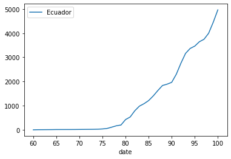

```python
df.plot(x ='date', y='Ecuador')
```

## EL modelo lineal

La regresión lineal es un algoritmo de aprendizaje supervisado que se utiliza en Machine Learning y en estadística. En su versión más sencilla, lo que haremos es «dibujar una recta» que nos indicará la tendencia de un conjunto de datos continuos.

Recordemos rápidamente la fórmula de la recta:

Y = mX + b

Donde Y es el resultado, X es la variable, m la pendiente (o coeficiente) de la recta y b la constante o también conocida como el «punto de corte con el eje Y» en la gráfica (cuando X=0) Ejemplo

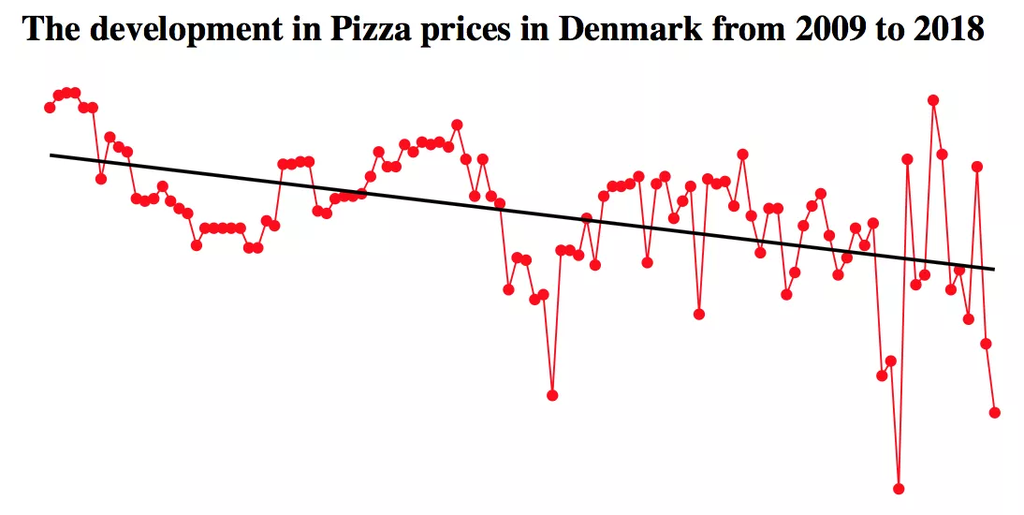

Recordemos que los algoritmos de Machine Learning Supervisados, aprenden por sí mismos y -en este caso- a obtener automáticamente esa «recta» que buscamos con la tendencia de predicción. Para hacerlo se mide el error con respecto a los puntos de entrada y el valor «Y» de salida real.

```python
x = list(df.iloc [:, 0]) # Fecha
y = list(df.iloc [:, 1]) # Numero de casos
# Creamos el objeto de Regresión Lineal
regr = linear_model.LinearRegression()

# Entrenamos nuestro modelo
regr.fit(np.array(x).reshape(-1, 1) ,y)

# Veamos los coeficienetes obtenidos, En nuestro caso, serán la Tangente
print('Coefficients: \n', regr.coef_)
# Este es el valor donde corta el eje Y (en X=0)
print('Independent term: \n', regr.intercept_)
# Error Cuadrado Medio
```

[output not shown]

```
Coefficients:
 [118.87532371]
Independent term:
 -8314.00908386207
```

De la ecuación de la recta y = mX + b nuestra pendiente «m» es el coeficiente y el término independiente «b»

```python
#Vamos a comprobar:
# Quiero predecir cuántos "Casos" voy a obtener por en el dia 100,
# según nuestro modelo, hacemos:
y_prediccion = regr.predict([[100]])
print(int(y_prediccion))
```

```
3573
```

```
[50 51 52 53 54 55 56 57 58 59 60 61 62 63 64 65 66 67 68 69 70 71 72 73
 74 75 76 77 78 79 80 81 82 83 84 85 86 87 88 89 90 91 92 93 94 95 96 97
 98 99]
```

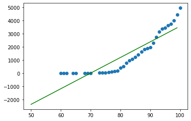

```python
#Graficar
plt.scatter(x, y)
x_real = np.array(range(50, 100))
print(x_real)
plt.plot(x_real, regr.predict(x_real.reshape(-1, 1)), color='green')
plt.show()
```

## El modelo logistico

A continuacion se puede apreciar un ejemplo de regresion logistica

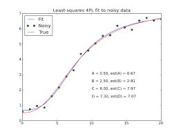

Definamos la función en Python y realicemos elprocedimiento de ajuste de curva utilizado para el crecimiento logístico.

```python
def modelo_logistico(x,a,b):
    return a+b*np.log(x)

exp_fit = curve_fit(modelo_logistico,x,y) #Extraemos los valores de los paramatros
print(exp_fit)
```

```
(array([-38372.64034049,   9054.16210819]), array([[14869437.0993886 , -3381438.58112044],
       [-3381438.58112044,   769827.20684087]]))
```

## Graficas

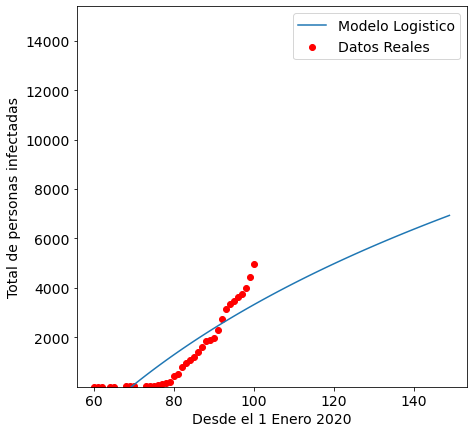

```python
pred_x = list(range(min(x),max(x)+50)) # Predecir 50 dias mas
plt.rcParams['figure.figsize'] = [7, 7]
plt.rc('font', size=14)
# Real data
plt.scatter(x,y,label="Datos Reales",color="red")
# Predicted exponential curve
plt.plot(pred_x, [modelo_logistico(i,exp_fit[0][0],exp_fit[0][1]) for i in pred_x], label="Modelo Logistico" )
plt.legend()
plt.xlabel("Desde el 1 Enero 2020")
plt.ylabel("Total de personas infectadas")
plt.ylim((min(y)*0.9,max(y)*3.1)) # Definir los limites de Y
plt.show()
```

## Modelo exponencial

Mientras que el modelo logístico describe un crecimiento de infección que se detendrá en el futuro, el modelo exponencial describe un crecimiento de infección imparable . Por ejemplo, si un paciente infecta a 2 pacientes por día, después de 1 día tendremos 2 infecciones, 4 después de 2 días, 8 después de 3 y así sucesivamente.

A continuacion se tiene un ejemplo de regresion exponencial

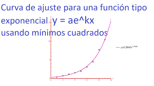

```
Predicción en el día 115: 27967.01024371809 contagiados
```

[figure not shown]

```python
# Implementar
def modelo_exponencial(x,a,b):
    return a+b*np.exp(b*x)

exp_fit = curve_fit(modelo_exponencial,x,y)
#print(exp_fit)

pred_x = list(range(0,max(x)+100))
plt.rcParams['figure.figsize'] = [7, 7]
plt.rc('font', size=14)


plt.scatter(x,y,label="Datos Reales",color="red")
# Predicted exponential curve
puntos=[modelo_exponencial(i,exp_fit[0][0],exp_fit[0][1]) for i in pred_x]
print ('Predicción en el día 115:', puntos[115], 'contagiados')
#print(x)

plt.plot(pred_x,puntos , label="Modelo Exponencial")
plt.legend()
plt.xlabel("Desde el 1 Marzo 2020")
plt.ylabel("Total de personas infectadas")
plt.ylim((-400,max(y)*6.1))
plt.xlim((min(x)*0.9,max(x)*1.5))
plt.plot(115,puntos[115], 'oy')
plt.show()
```

## Modelo polinomial

Predicción de una variable de respuesta cuantitativa a partir de una variable predictora cuantitativa, donde la relación se modela como una función polinomial de orden n (esto significa que pueden tener de diferentes exponenciales o grados y se debe ir probando)

Se puede tener una ecuacion con diferentes grados

y = a0 + a1x + a2x^2 + a3x^3 + … + anx^n + ε

Ejemplo de una regresion polinomica de grado 4.

[figure not shown]

```
Predicción en el día 115: 37732.22785092518 contagiados
```

[figure not shown]

```python
# Implementar


# Se puede implementar modelos adicionales, en caso de ser asi explicar o dar una introduccion del modelo aplicado

# Se tomara como puntos adicionales al trabajo.

from sklearn.linear_model import LinearRegression
from sklearn.preprocessing import PolynomialFeatures

pf = PolynomialFeatures(degree = 6)    # usaremos polinomios de grado 6
X = pf.fit_transform(np.array(x).reshape(-1, 1))

regresion_lineal = LinearRegression()

regresion_lineal.fit(X, y)

#print('w = ' + str(regresion_lineal.coef_) + ', b = ' + str(regresion_lineal.intercept_))



pred_x = list(range(0,max(x)+100))

puntos = pf.fit_transform(np.array(pred_x).reshape(-1, 1))
prediccion_entrenamiento = regresion_lineal.predict(puntos)
print ('Predicción en el día 115:', prediccion_entrenamiento[115], 'contagiados')
#print( x)

plt.plot(puntos, prediccion_entrenamiento, color='green')
plt.scatter(x,y,label="Datos Reales",color="red")
plt.ylim((-300,max(y)*7.9))
plt.xlim((min(x)*0.9,max(x)*1.5))
plt.xlabel("Desde el 1 Marzo 2020")
plt.ylabel("Total de personas infectadas")
plt.plot(115,prediccion_entrenamiento[115], 'oy')
plt.show()
```

# Analisis

### Modelo Polinomico

La regresión polinomial se ajusta a una relación no lineal entre el valor de x y la correspondiente media condicional de y, denotada E (y | x), lo cual se ha utilizado para describir la progresión de esta epidemia que denotan el crecimiento de personas contagiadas en el país. Realizando un calculo a a partir de los datos encontrados. Es necesario tomar en cuenta el grado del polinomio con fin de encontrar una gráfica que tenga mayor ajuste a la tasa de crecimiento. Para poder realizar el cálculo del modelo se debe usar las siguientes librerías: from sklearn.linear_model import LinearRegression from sklearn.preprocessing import PolynomialFeatures

# Conclusiones

# Criterio personal (politico, economico y social de la situacion)

Evidentemente el factor político juega un papel fundandamtal en el; control de focos de infección, organización social, respuesta a posibles problemas sociales y/o ecónimicos, programas de organización y solventación ecónomica. De la pronta y acertada respuesta gubernamental dependerá la situación general del país, sin embargo, Ecuador, es el país más afectado de toda la región, esto evidencia el caos e inenptitud de las autoridades al momento de reaccionar y actuar, en consecuencia, se observa el colpaso de los sistemas sociopliticos del país, lo que conlleva a una grave desorientación social, pudiendo esta, ser un problema de gran peso agregado a la ya fatídica e incotrlable situación, esto, nos abliga como ciudadonos críticos a reepemzar sobre nuestro accionar y tener mucho cuidado con la información que creamos y recibimos.

**Estudiante:** Lucy Garay

# Referencias

- https://www.researchgate.net/publication/340092755_Infeccion_del_Covid-19_en_Colombia_Una_comparacion_de_modelos_logisticos_y_exponenciales_aplicados_a_la_infeccion_por_el_virus_en_Colombia
- https://www.aprendemachinelearning.com/regresion-lineal-en-espanol-con-python/